# Event Driven Pricing Game

# Scrap

```julia
indmax(splitup[2])
```

```
3220
```

```julia
perfect2 =Int64[]
for ix in 1:length(splitup2[2])
    if splitup2[2][ix]==1
        push!(perfect2, ix)
    end
end
```

```julia
l
```

```
l not defined
while loading In[93], in expression starting on line 1
```

```julia
perfect2
```

```
9-element Array{Int64,1}:
  1768
  1878
  6294
 13366
 19273
 20515
 24040
 28392
 33117
```

```julia
diff = 0
for ix in perfect2
    thisone = splitup2[3][ix]-splitup2[4][ix]
    diff += thisone
    print(splitup2[3][ix], "    ", splitup2[4][ix], "\n")
    print("thisdiff=",  "  ", thisone, "\n")
    print("total diff =   ", diff)
end
print(splitup2[3][1768], "\n")
print(splitup2[4][1768]);
```

```
3486.532385846018    2199.1898936648417
thisdiff=  1287.342492181176
total diff =   1287.3424921811763269.467536245877    1450.9030823796386
thisdiff=  1818.5644538662384
total diff =   3105.90694604741472112.2389317500556    2404.7491091288894
thisdiff=  -292.51017737883376
total diff =   2813.3967686685812547.229356103017    4317.62124919573
thisdiff=  -1770.3918930927134
total diff =   1043.00487557586764309.604047435027    1649.4460342640043
thisdiff=  2660.1580131710225
total diff =   3703.162888746893838.9451905656742    1645.1749717291996
thisdiff=  2193.7702188364747
total diff =   5896.9331075833653510.9314978607176    2018.047863870855
thisdiff=  1492.8836339898626
total diff =   7389.8167415732283099.808275271655    2033.701064603574
thisdiff=  1066.107210668081
total diff =   8455.9239522413081897.4390717963167    1932.7352623384284
thisdiff=  -35.29619054211162
total diff =   8420.6277616991973486.532385846018
2199.1898936648417
```

```julia
print(thisone)
```

```
thisone not defined
while loading In[109], in expression starting on line 1
```

```julia
print(splitup[3][5989], "\n")
print(splitup[4][5989]);
```

```
2991.6197772968176
2032.3739061026592
```

```julia
params
```

```
Dict{Any,Any} with 19 entries:
  "p2statespace"       => ASCIIString["Memory1"]
  "p1statespace"       => ASCIIString["Memory1"]
  "market_change_rate" => 0.25
  "p1tomarket"         => 1.0
  "trembling"          => true
  "market_state_space" => [(50,1,0.5),(30,1,0.5),(10,1,0.5)]
  "p1c"                => 1.0
  "p1quantities"       => [2,6,10,14,18,22,26,30,34,38,42,46,50]
  "mkt_to_p1"          => 1.0
  "numprofiles"        => 5000
  "p2c"                => 1.0
  "discount"           => 0.25
  "mkt_to_p2"          => 1.0
  "numalt"             => 30
  "eu_tmax"            => 20
  "p2tomarket"         => 1.0
  "tremble_prob"       => 0.1
  "eunumsims"          => 1000
  "p2quantities"       => [2,6,10,14,18,22,26,30,34,38,42,46,50]
```

Again, I think the reason we do not see such a difference here is because of the non-credible threat scenarios. Although player 1 will receive messages from the market first and his quantity will get to the market first, there are still many strategies for player 1 and player 2 that have high intelligence (i.e. Nash equilibrium) but are not the Stackelberg scenario.

One possible solution to this is some of the "tremling hand" PGT calculations we used before.

Though the trembling hand PGT approach does have its limitations, let's see what happens when we allow the players to tremble.

```julia
addprocs(7)
@everywhere require("parallelrequire_CournotPGT.jl");
```

[output not shown]

```julia
params["mkt_to_p1"]=10.
params["p1tomarket"]= 10.
params["numprofiles"]= 200;
```

```julia
ci_result3 = pmap(CI_PGT, [params, params, params, params, params, params, params]);
```

```julia
splitup3 = split_pgt_parallel(ci_result3);
```

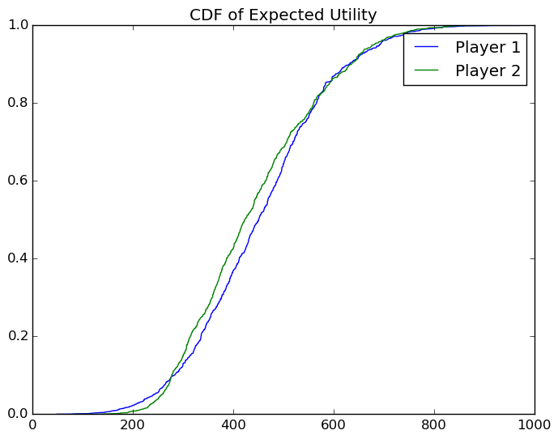

```julia
x,y= plot_intelligence_cdf(splitup3[2], splitup3[3]);
plot(x,y, label="Player 1");
x,y= plot_intelligence_cdf(splitup3[2], splitup3[4]);
plot(x,y, label="Player 2")
ylim(0,1)
title("CDF of Expected Utility")
legend();
```

The difference in player 1 is not as pronounced as in a Stackelberg game. One reason for this is that not enough relative weight is given to high intelligence profiles. In other words, the next experiment to run is to change the exponent parameter in the intelligence calculations.

# Executive Summary

- I created an event-driven Cournot model
- I used a confidence interval based PGT to estimate intelligences for strategy profiles
- I estimated the expected utility for players under different parameter sets.
- I estimated expected utilities using trembling hand PGT
- There was little change among all experiments

# Scrap

- First we need to fix the player object
  - We want the player type to set a current strategy and have a container for all possible strategies
- We need a function that simulates the network up to a prespecified number of time steps where player strategies are given.
- We need a way to sample player strategies
  - Strategies are mapings from (input, state) to (output, state).
  - To get a full set of strategies, we need to know all possible messages a player can receive.
  - Need a function that takes as an input all SFTs in a game and outputs the pure strategy space for all players.
- We need a way to compute expected utility for given strategies
  - This just requires simulating a bunch of times and averaging the output
  - Produce a graph that shows the convergence of expected utility vs the number of simulation
  - Produce a graph the shows the convergence of expected utility for a given number of time steps
- Then we need a PGT algorithm
  - Once the above is implemented this should be simple:
    - Setup containers (~ 5 lines of code)
    - Sample a strategy profile for both players (two lines of code)
    - Call the EU function (1 line of code)
    - Sample alternatives for player 1 and compute EU (2 lines)
    - Sample alternatives for player 2 and compute EU (2 lines)
    - In the process, remember all EUs computed previously
- **If** we can generate a list of all proiles for each player, any records (expected utilities, intelligences and such) should be a dictionary with indices as keys. That way we save memory instead of turning an entire dictionary into a string.

```julia
i = readcsv("intel1")
p1 = readcsv("p11")
```

```
14000x1 Array{Float64,2}:
 491.4
 565.476
 206.591
 360.069
 592.697
 329.199
 224.635
 390.848
 423.369
 213.797
 539.761
 549.54
 510.72
   ⋮
 333.039
 742.592
 526.603
 359.64
 404.353
 628.549
 268.873
 391.413
 594.924
 274.436
 134.885
 290.234
```

```julia
CI_PGT(params)
```

[output not shown]